# Binomial Distribution Response to Urban Heat

Joey Hulbert

Last Update: 2024-02-24

| [Welcome](https://jmhulbert.github.io/redhot) | [Data](https://jmhulbert.github.io/redhot/data) | [Analyses](https://jmhulbert.github.io/redhot/analyses) | [Discussion](https://jmhulbert.github.io/redhot/discussion) | [Maps](https://jmhulbert.github.io/redhot/maps) |
| --- | --- | --- | --- | --- |

```r
library(tidyverse)
library(corrplot)
library(knitr)
library(kableExtra)
library(gghalves)
library(patchwork)
library(scales)
library(glmmTMB)
library(bbmle)
library(DHARMa)
```

# Purpose

The purpose of this page is to summarize an investigation of **tree health categories** as a *categorical* response to urban heat (temperatures).

Response variable: category: *healthy, unhealthy*

# Read Data

```r
data <- read.csv('https://raw.githubusercontent.com/jmhulbert/redhot/main/data/urban-data-modified.csv')
```

# Wrangle Data

## Remove dead trees

```r
# Remove Dead Trees
data.w.dead <- data
data <- data %>% filter(field.tree.canopy.symptoms!="Tree is dead") %>% filter(field.dieback.percent<100) %>% droplevels()
```

```r
data$binary.tree.canopy.symptoms <- as.factor(data$binary.tree.canopy.symptoms)
levels(data$binary.tree.canopy.symptoms)
```

```
## [1] "Healthy"   "Unhealthy"
```

# Data Visualization

## Binary Tree Condition Categories

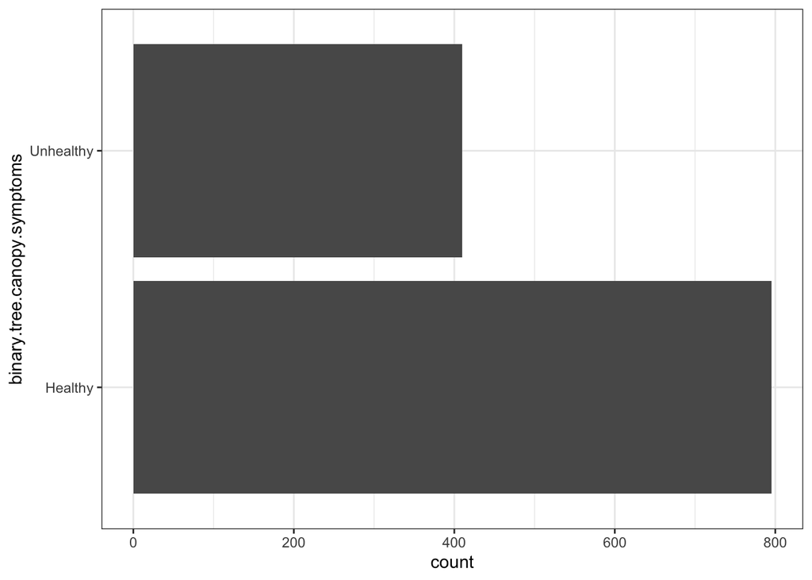

```r
ggplot(data,aes(binary.tree.canopy.symptoms))+geom_histogram(stat="count")+theme_bw()+coord_flip()
```

```r
p1 <-ggplot(data,aes(binary.tree.canopy.symptoms,dist.from.mean.af, fill=binary.tree.canopy.symptoms ))+geom_boxplot(alpha=0.5)+theme_bw()+coord_flip() + scale_fill_manual(name="Tree Condition",values=c("#7fcdbb","#fe9929"))+guides(fill=FALSE) +labs(x="Tree Condition",y=NULL)
p2 <-ggplot(data,aes(dist.from.mean.af,fill=binary.tree.canopy.symptoms))+geom_density(alpha=0.5) + scale_fill_manual(name="Tree Condition",values=c("#7fcdbb","#fe9929")) +theme_bw() +labs(x="Distance from Mean Afternoon Temperature") +guides(fill=FALSE)
```

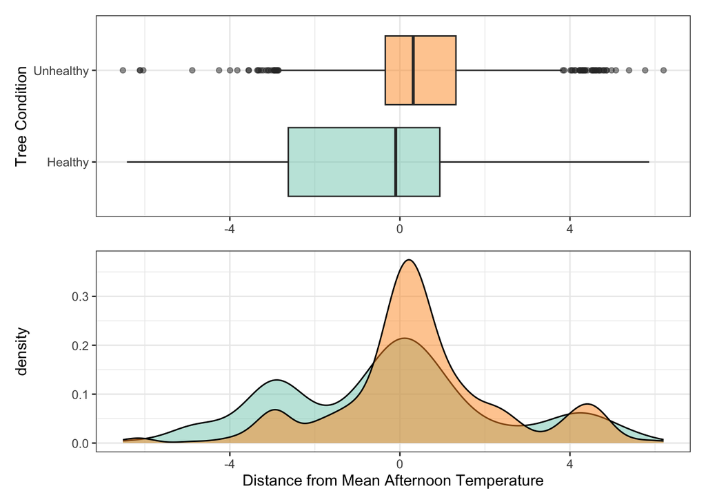

```r
p1 / p2
```

## Reclassified Tree Condition Categories

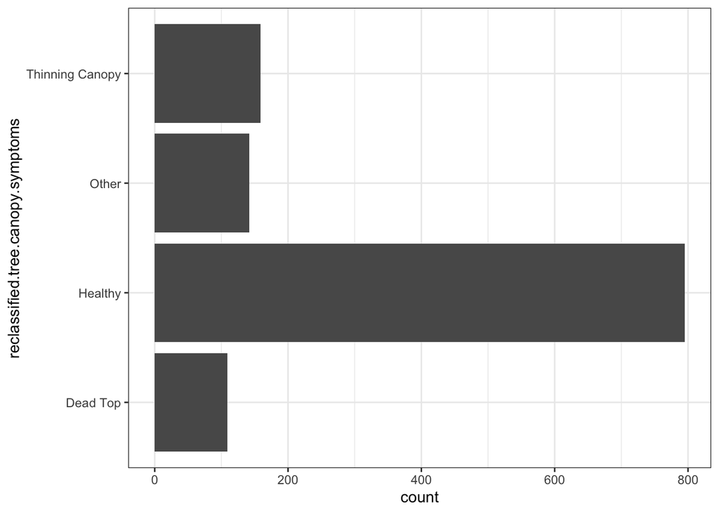

```r
ggplot(data,aes(reclassified.tree.canopy.symptoms))+geom_histogram(stat="count")+theme_bw()+coord_flip()
```

```r
data$top.dieback <- as.factor(data$top.dieback)
data$thinning <- as.factor(data$thinning)
```

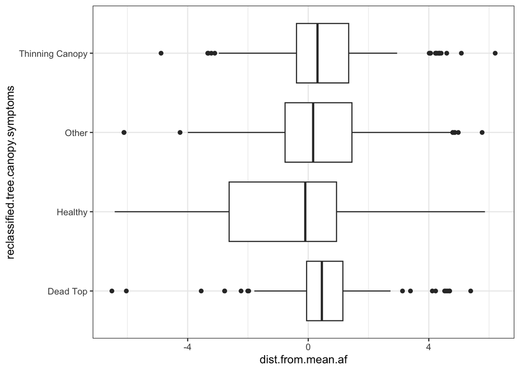

```r
ggplot(data,aes(reclassified.tree.canopy.symptoms,dist.from.mean.af ))+geom_boxplot()+theme_bw()+coord_flip()
```

## Temp and Site Type

```r
king <- data %>% filter(Area=="King County")
```

```r
king <- king %>% filter(field.optional...site.type=="Urban"|field.optional...site.type=="Suburban"|field.optional...site.type=="Rural")
```

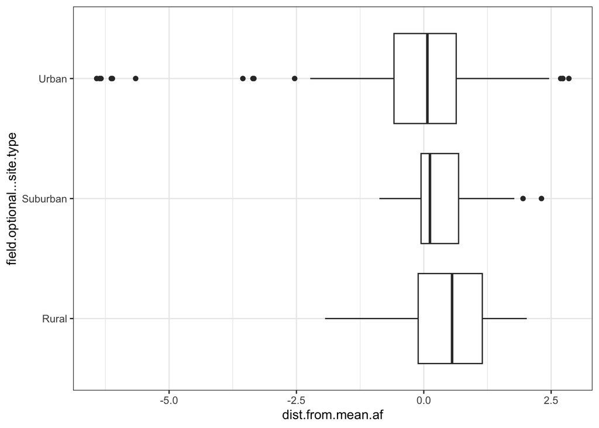

```r
ggplot(king,aes(field.optional...site.type,dist.from.mean.af ))+geom_boxplot()+theme_bw()+coord_flip()
```

# Analyses

## Fit Models

```r
binomial.daily <- glmmTMB(binary.tree.canopy.symptoms ~ dist.from.mean.daily + (1|Area),family=binomial,data=data)
binomial.am <- glmmTMB(binary.tree.canopy.symptoms ~ dist.from.mean.am + (1|Area),data=data,family=binomial)
binomial.af <- glmmTMB(binary.tree.canopy.symptoms ~ dist.from.mean.af + (1|Area),data=data,family=binomial)
binomial.pm <- glmmTMB(binary.tree.canopy.symptoms ~ dist.from.mean.pm + (1|Area),data=data,family=binomial)
```

## Compare Models

```r
AICtab(binomial.daily,binomial.am,binomial.af,binomial.pm)
```

```
##                dAIC df
## binomial.af     0.0 3
## binomial.daily 20.6 3
## binomial.am    22.9 3
## binomial.pm    23.9 3
```

Afternoon heat was the best fit

## Model 1: health and heat

```r
#binomial.af <- glmmTMB(binary.tree.canopy.symptoms ~ dist.from.mean.af + (1|Area),data=data,family=binomial)
```

### Summary

```r
summary(binomial.af)
```

```
##  Family: binomial  ( logit )
## Formula:          binary.tree.canopy.symptoms ~ dist.from.mean.af + (1 | Area)
## Data: data
##
##      AIC      BIC   logLik deviance df.resid
##   1482.7   1498.0   -738.4   1476.7     1202
##
## Random effects:
##
## Conditional model:
##  Groups Name        Variance Std.Dev.
##  Area   (Intercept) 0.2112   0.4595
## Number of obs: 1205, groups:  Area, 3
##
## Conditional model:
##                   Estimate Std. Error z value Pr(>|z|)
## (Intercept)       -0.70159    0.27300  -2.570   0.0102 *
## dist.from.mean.af  0.14499    0.02858   5.073 3.91e-07 ***
## ---
## Signif. codes:  0 '***' 0.001 '**' 0.01 '*' 0.05 '.' 0.1 ' ' 1
```

Tree health is associated with urban heat. The probability of success (tree categorized as unhealthy) increases with urban heat

Unhealthy trees are considered success (1) because it is the second level. The probability of failure (0) is the first level (Healthy).

```r
levels(data$binary.tree.canopy.symptoms)
```

```
## [1] "Healthy"   "Unhealthy"
```

The probability of a tree being classified as unhealthy increases with urban temperature.

### Visualize effects of predictors

First, generate predictions from model

```r
# Create a data frame for predictions
new.data <- expand.grid(
  dist.from.mean.af = seq(min(data$dist.from.mean.af), max(data$dist.from.mean.af), length.out = 100),  # keeping predictor2 constant at its mean
  Area = 0  # assuming random effect is zero for prediction
)
```

```r
new.data$predicted_response <- predict(binomial.af, newdata = new.data, type = "response")
```

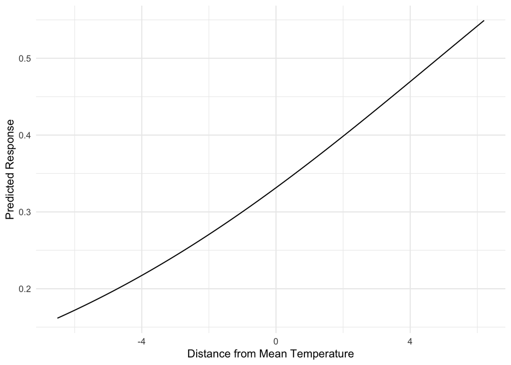

```r
ggplot(new.data, aes(x = dist.from.mean.af, y = predicted_response)) +
  geom_line() +
  labs(x = "Distance from Mean Temperature", y = "Predicted Response") +
  theme_minimal()
```

The probability of tree being classified as unhealthy increases with distance from mean af

## Model 2: top dieback and heat

```r
top.dieback.binomial.af <- glmmTMB(top.dieback ~ dist.from.mean.af + (1|Area),data=data,family=binomial)
```

### Summary

```r
summary(top.dieback.binomial.af)
```

```
##  Family: binomial  ( logit )
## Formula:          top.dieback ~ dist.from.mean.af + (1 | Area)
## Data: data
##
##      AIC      BIC   logLik deviance df.resid
##    700.5    715.8   -347.2    694.5     1202
##
## Random effects:
##
## Conditional model:
##  Groups Name        Variance Std.Dev.
##  Area   (Intercept) 0.4419   0.6647
## Number of obs: 1205, groups:  Area, 3
##
## Conditional model:
##                   Estimate Std. Error z value Pr(>|z|)
## (Intercept)       -2.53476    0.40450  -6.266  3.7e-10 ***
## dist.from.mean.af  0.20344    0.05895   3.451 0.000558 ***
## ---
## Signif. codes:  0 '***' 0.001 '**' 0.01 '*' 0.05 '.' 0.1 ' ' 1
```

Tree health is associated with urban heat. The probability of success (tree categorized as unhealthy) increases with urban heat

```r
levels(data$top.dieback)
```

```
## [1] "No"  "Yes"
```

```r
p3 <-ggplot(data,aes(top.dieback,dist.from.mean.af, fill=top.dieback ))+geom_boxplot(alpha=0.5)+theme_bw()+coord_flip() + scale_fill_manual(name="Top Dieback",values=c("#7fcdbb","#fe9929"))+guides(fill=FALSE) +labs(x="Top Dieback",y=NULL)
```

```r
p4 <-ggplot(data,aes(dist.from.mean.af,fill=top.dieback))+geom_density(alpha=0.5) + scale_fill_manual(name="Top Dieback",values=c("#7fcdbb","#fe9929")) +theme_bw() +labs(x="Distance from Mean Afternoon Temperature") +guides(fill=FALSE)
```

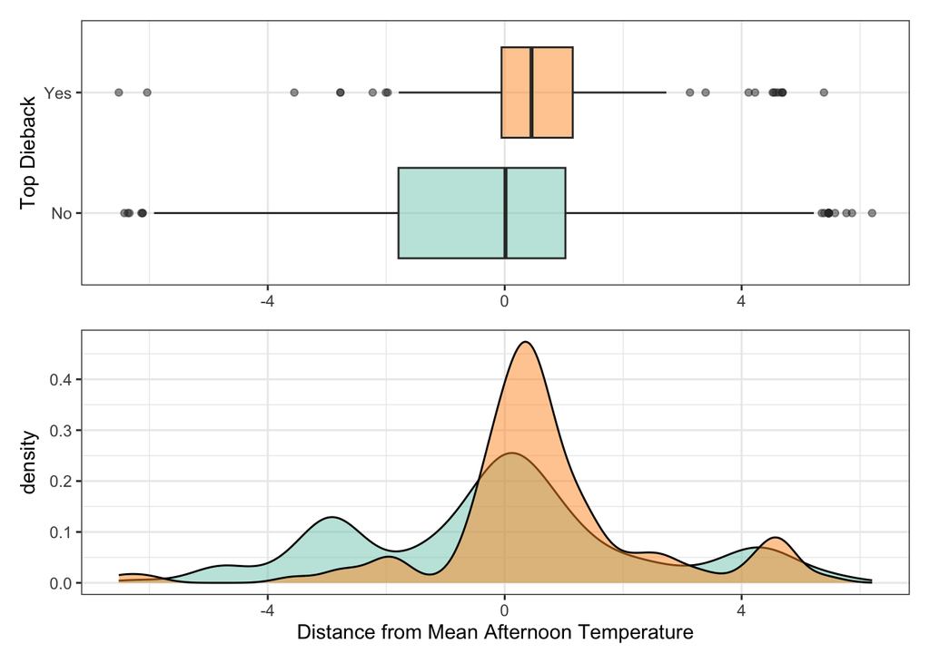

```r
p3 / p4
```

The probability of a tree having top dieback increases with urban temperature.

### Visualize effects of predictors

First, generate predictions from model

```r
# Create a data frame for predictions
new.data.2 <- expand.grid(
  dist.from.mean.af = seq(min(data$dist.from.mean.af), max(data$dist.from.mean.af), length.out = 100),  # keeping predictor2 constant at its mean
  Area = 0  # assuming random effect is zero for prediction
)
```

```r
new.data.2$predicted_response <- predict(top.dieback.binomial.af, newdata = new.data.2, type = "response")
```

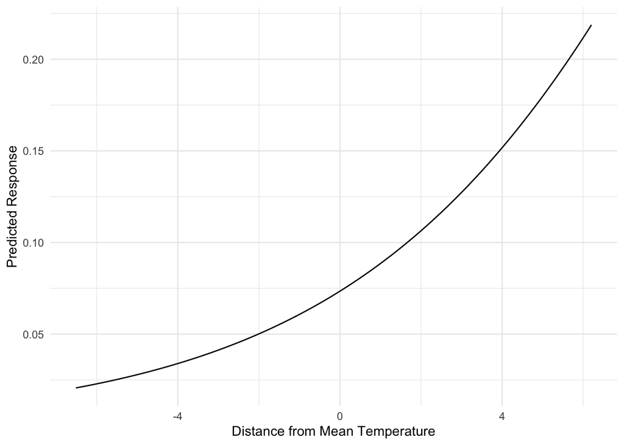

```r
ggplot(new.data.2, aes(x = dist.from.mean.af, y = predicted_response)) +
  geom_line() +
  labs(x = "Distance from Mean Temperature", y = "Predicted Response") +
  theme_minimal()
```